# Visualizing Bike Share Data in San Francisco

by Julio Uribe

## Dataset Overview

This data set explores bike usage from Ford GoBike data. This data set contains over 1.8 million entries of bike usage from 2018. The data was sampled to 100,000 rows for faster pandas operations. I made use of various plot types to explore this data set. From barcharts and histograms to gps based heat maps. The next few slides are some of my favorite plots that provide the most insight on how customers use bike share to address their morning commute, how subscription models affect trip duration, and how bike usage fares throughout the week and across different parts of the year.

## User Types as a Proportion

First, I wanted to see what pricing models customers subscribed to. Ford GoBikes offers a monthly rate, and a flat rate for single rides. Both of these come with certain rules and restrictions which can affect how riders plan their trips. Most riders opt in for a subscription model which indicates that customers are making bike share a part of their routine.

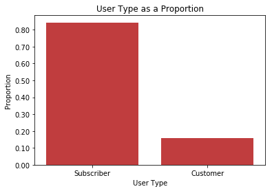

```python
n_points = sf_bikes.shape[0]
max_count = sf_bikes['user_type'].value_counts().max()
max_prop = max_count / n_points

# generate tick mark locations and names
tick_props = np.arange(0, max_prop+0.1, 0.10)
tick_names = ['{:0.2f}'.format(v) for v in tick_props]

# create the plot
base_color = sb.color_palette()[3]
plt.yticks(tick_props * n_points, tick_names)
sb.countplot(data = sf_bikes, x = 'user_type', color = base_color)
plt.ylabel('Proportion')
plt.xlabel('User Type')
plt.title('User Type as a Proportion');
```

## Usage Throughout the Day

First thing I wanted to visualize was bike usage across the day. When are bikes being used the most? There's spikes in usage in the morning and afternoon commute times but there's also a steady stream of usage during the day and evening.

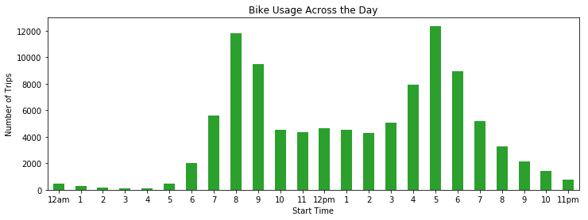

```python
plt.figure(figsize = (12,4))
base_color = sb.color_palette()[2]
# hours = ['12am', '1am', '2am', '3am', '4am', '5am', '6am', '7am', '8am', '9am', '10am', '11am',
#         '12pm', '1pm', '2pm', '3pm', '4pm', '5pm', '6pm', '7pm', '8pm', '9pm', '10pm', '11pm']
hours = ['12am', '1', '2', '3', '4', '5', '6', '7', '8', '9', '10', '11',
        '12pm', '1', '2', '3', '4', '5', '6', '7', '8', '9', '10', '11pm']
sf_bikes.groupby(sf_bikes.start_time.dt.hour).bike_id.count().plot(kind='bar', color = base_color);
# get the plot axes information
ax = plt.gca()
# get xtick positions
pos = ax.get_xticks().tolist()
# get xtick labels
labs = ax.get_xticklabels()
# change the xticks
plt.xticks(pos,hours, rotation = 'horizontal')
plt.xlabel('Start Time')
plt.ylabel('Number of Trips')
plt.title('Bike Usage Across the Day');
```

## Usage by Month

I also wanted to learn how different season could affect riders. Are people riding more in warmer climates? Do people choose other alternative in colder or wet seasons? We see the highest usage in the summer months and lower numbers around the seasons where San Francisco tends to get more rain.

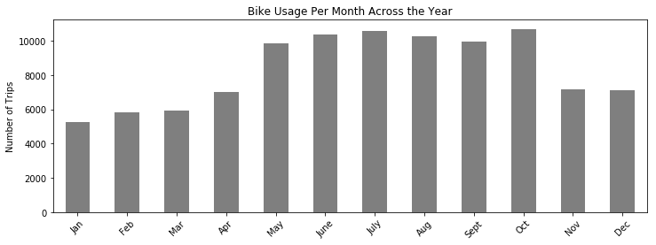

```python
plt.figure(figsize = (12,4))
base_color = sb.color_palette()[7]
months = ['Jan', 'Feb', 'Mar', 'Apr', 'May', 'June', 'July', 'Aug', 'Sept', 'Oct', 'Nov', 'Dec']
sf_bikes.groupby(sf_bikes.start_time.dt.month).bike_id.count().plot(kind='bar', color = base_color)
# get the plot axes information
ax = plt.gca()
# get xtick positions
pos = ax.get_xticks().tolist()
# get xtick labels
labs = ax.get_xticklabels()
# change the xticks
plt.xticks(pos,months, rotation = '45')
plt.xlabel('')
plt.ylabel('Number of Trips')
plt.title('Bike Usage Per Month Across the Year');
```

## Heat Map of Trip Duration by Age

This plot was one of my favorites. While it wasn't as related to exploring commute related info, it produced a fairly wholesome result. My initial impression was that younger riders would be riding for longer trips. The result was that groups of all ages are riding for about the same amount of time. Sure there's more people around their early 30s making up a larger share of the trips but all groups displayed an interest in various lengths of bike rides.

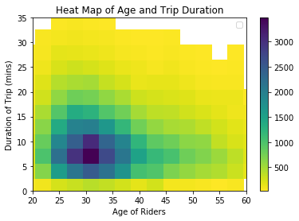

```python
bins_x = np.arange(17.5, 70.5+3, 3)
bins_y = np.arange(-0.5, 100.5+3, 3)
plt.hist2d(data = sf_bikes, x = 'age', y = 'duration_min',
           bins = [bins_x, bins_y], cmap = 'viridis_r', cmin = 35, label = 'Number of Trips')
plt.colorbar()
plt.xlim(20, 60)
plt.ylim(0, 35)
plt.xlabel('Age of Riders')
plt.ylabel('Duration of Trip (mins)')
plt.title("Heat Map of Age and Trip Duration");
```

## Subscription Type Difference Clearly Illustrated by Trip Duration Spread

Pricing models can play a heavy role in how people plan their trips and bike usage. It was really interesting to see how closely subscriber users tended to end their trips just above the 10 min mark. I had trouble pulling up pricing model data from 2018 but I'm led to believe that subscribers had to limit their trips before the 15 minute mark to avoid additional fees. Meanwhile, flat rate customers enjoyed their bikes to up to 30 mins before experiencing higher fees.

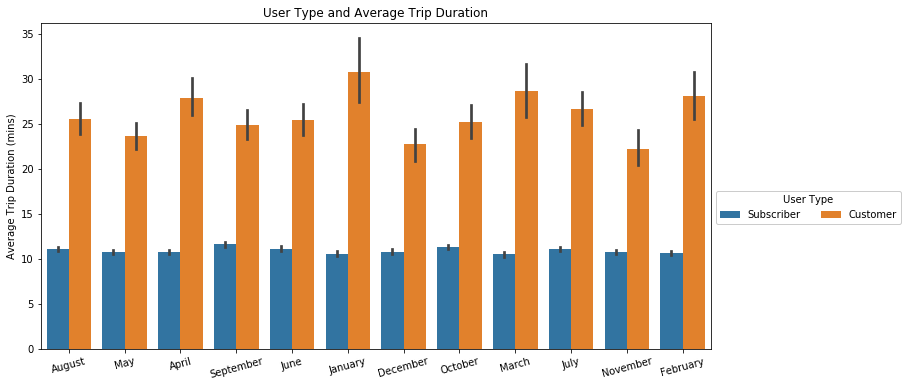

```python
sf_bikes['month'] = sf_bikes.start_time.dt.strftime("%B")
plt.figure(figsize = (12, 6))
ax = sb.barplot(data = sf_bikes, x = 'month', y = 'duration_min', hue = 'user_type')
ax.legend(loc = 0, ncol = 3, framealpha = 1, title = 'User Type', bbox_to_anchor = (1.0, 0.5));
plt.xticks(rotation = 15)
plt.xlabel('')
plt.ylabel('Average Trip Duration (mins)')
plt.title('User Type and Average Trip Duration');
```

## Average Trip Duration Across the Week and Gender

The following barplot showed the average trip duration across the week with gender as color. My main take away here was that female riders tended to ride for longer on weekends. While all riders tended to limit their trips to below 15 minutes during the week, female riders didn't mind going over this limit on the weekend. Perhaps its a reflection of riding for leisure and not worring so much about the extra potential fee. What's an extra dollar or two when you're enjoying a bike ride on a beautiful day?

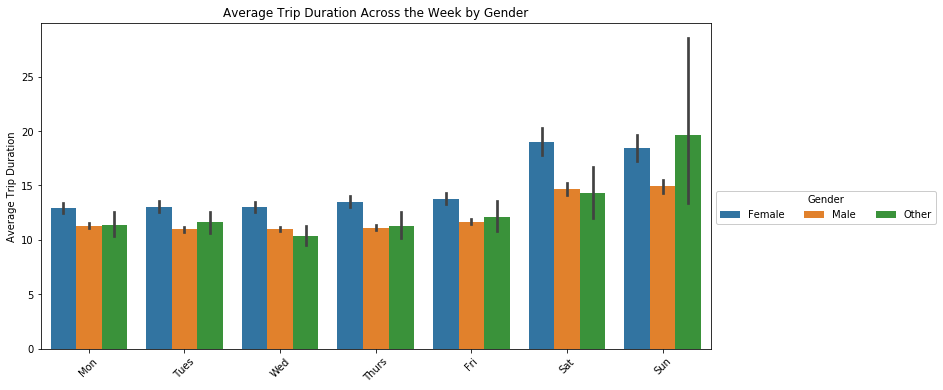

```python
plt.figure(figsize = (12, 6))
weekdays = ['Mon', 'Tues', 'Wed', 'Thurs', 'Fri', 'Sat', 'Sun']
sf_bikes['day'] = sf_bikes.start_time.dt.weekday
ax = sb.barplot(data = sf_bikes, x = 'day', y = 'duration_min', hue = 'member_gender')
ax.legend(loc = 0, ncol = 3, framealpha = 1, title = 'Gender', bbox_to_anchor = (1.0, 0.5));
axis = plt.gca()
# get xtick positions
pos = axis.get_xticks().tolist()
plt.xticks(pos, weekdays, rotation = '45')
plt.xlabel('')
plt.ylabel('Average Trip Duration')
plt.title('Average Trip Duration Across the Week by Gender');
```

## Morning Commute Conveyed by through Heat Maps

The last thing I wanted to explore was a heat map using a map of San Francisco and plotting the different docking locations. I used the library Folium to grab an image of a map from Open Street Map and then I plotted the different locations and created a heat map. The result is a story of people grabbing a bike near a public transit location and riding them to different parts of San Francisco for work, school, or other activies. The next few slides show how people move around in the morning using GoBikes.

## Bike Start Locations During the Morning Commute

Are riders using GoBikes to connect them to public transportation or other commute options? The first heat map shows that there is a decent amount of activity spread out in San Francisco but more activity near public transit locations. There's a concentration near Bart stations, Cal Train 4th and King location, and other spots on Market. A solid highlight is the 22nd Street Cal Train Station in Dogpatch. We'll have to see where the morning trips end to see where people are going.

```python
bikes_short = AM.sample(3000, replace=True)

# grab image of SF map
sf = folium.Map(location=[37.775204, -122.418747],
                    zoom_start = 13)
# build df to plug into heatmap func from sampled data to make processing faster
heat_df = bikes_short[['start_station_latitude', 'start_station_longitude']]
heat_df = bikes_short.dropna(axis=0, subset=['start_station_latitude', 'start_station_longitude'])

# List comprehension to make out list of lists
heat_data = [[ row['start_station_latitude'],row['start_station_longitude']] for index, row in heat_df.iterrows()]

# Plot it on the map
HeatMap(heat_data).add_to(sf)

# Display the map
sf
```

[interactive chart not shown]

## Bike End Locations During Morning Commute

Looking at the end location, we see a lot of activity near downtown, Market, Financial District, and SOMA. There is more of a spread of where people end up. These locations also tend to be where people work. Some of the more industrial parts of San Francisco. It seems like many people are using GoBikes to connect their train/Bart ride to their work, school, or other activity.

```python
# sample smaller set for easier loading
AM_end = AM.sample(3000, replace=True)

# grab image of SF map
sf = folium.Map(location=[37.775204, -122.418747], zoom_start = 13)
# build df to plug into heatmap func from sampled data to make processing faster
heat_df = AM_end[['end_station_latitude', 'end_station_longitude']]
heat_df = AM_end.dropna(axis=0, subset=['end_station_latitude', 'end_station_longitude'])
# List comprehension to make out list of lists
heat_data = [[ row['end_station_latitude'],row['end_station_longitude']] for index, row in heat_df.iterrows()]

# Plot it on the map and display
HeatMap(heat_data).add_to(sf)
sf
```

[interactive chart not shown]

## Closing Summary

I learned a lot while exploring this data set. Bike share has really increased in popularity over the last few years and is very helpful for addressing last mile problems while commuting in a city. I've personally haven't used bike share nearly as much because I own a bike myself but maybe I should consider this option more. It was interesting to see how much of an effect the different subscription models had on how riders used this service. Depending on city needs, companies can adjust their pricing models to influence how their service is used in a way that could potentially compliment the city's transit needs. Besides adressing the usual work commute, I wonder what other transportation gaps exist that bike share can address.